# Formatting Figures

Johan Larsson

# 1 Captions

Figures in a text document should always be accompanied by a *caption*: a description (in text) of the visualization. Figure 1 shows an example of a simple caption.

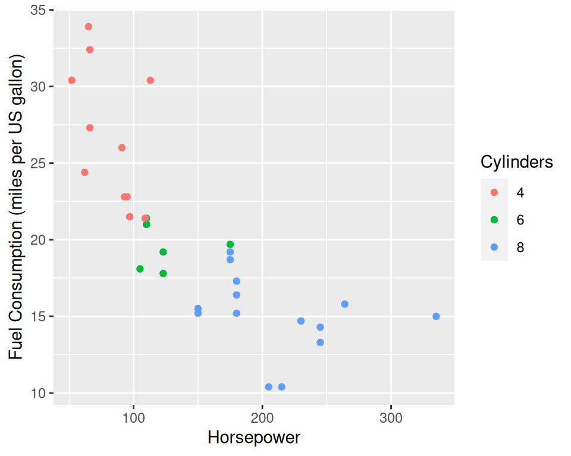

Figure 1: Horsepower and fuel consumption. Each dot represents a motor car from the 1974 Motor Trend US magazine.

## 1.1 Basics

Captions should, at a minimum, give enough information for the reader to be able to understand *reasonably well* what the figure shows. Do not expect every reader to have followed along with your text and remembered the details as they consider your figures. But note that I write “reasonably well” here because some figures may just be too advanced to cover in a caption and therefore require the reader to read more of the text in order to grasp all details. It is also important to keep in mind that some readers actually *will* have read all of the text and do not deserve to have all this information repeated to them.

It helps to consider the caption and the visualization as a single entity. If you have, for instance, written the units of the variables on the axes in the axis titles, then you do need not to restate them in the caption. Similarly, if there is a guide (such as a legend) coupling color to a variable in the visualization, then there is no need to mention this (again) in the caption.

### 1.1.1 Titles

A common and effective practice is to start the caption with a title that succinctly sums up what the figure is about. This title does not need to be a complete sentence. The caption in Figure 1 has exactly such a caption: “Horsepower and fuel consumption”. You may be tempted to use `ggtitle()` or `labs(title = ...)` in ggplot2 to write your titles, but please refrain from doing so in this course. The titles you end up with using these functions are not appropriate for figures in text documents (although they are fine for infographics and presentations).

## 1.2 Formalities

### 1.2.1 Placement

It is almost a universal standard that captions for figures go *below* the figure and we follow this standard in this course. The reason for this is that figures are considered to be read from below and up. Contrast this with tables, which are read from top down and for which captions should instead go above the table.

### 1.2.2 Numbering

Figures (and their captions) should be numbered sequentially. Doing so allows you to easily reference them in the text. This is especially important when figures do not appear directly before or after the text or change position as you edit the text (which can happen when you use R Markdown).

## 1.3 Practicalities

Depending on how you are constructing your assignments for this course, there are several different options for adding captions to your figures.

## 1.4 Caption Styles

Beyond the basics that we have now covered there is actually quite a bit of freedom when it comes to writing your captions. Some authors like to use captions to convey new information, highlighting aspects of the figures that may not be mentioned elsewhere in the text. Other authors prefer to only convey the formal aspects of the visualization in their captions, delegating analysis and discussion to the body text. Here it is up to you to choose how you want your captions.

### 1.4.1 R Markdown

If you are using R Markdown, please use the `fig.cap` argument in the R Markdown chunk header to provide a caption. A code chunk for a figure might look something like this:

````
```{r, fig.cap = "Engine displacement and numbers of cylinders for 38 popular car models from <https://fueleconomy.gov>. Engine displacement is given in litres."}
library(tidyverse)

mpg %>%
  ggplot(aes(cyl, displ)) +
  geom_point() +
  labs(x = "Number of Cylinders", y = "Engine Displacement")
```
````

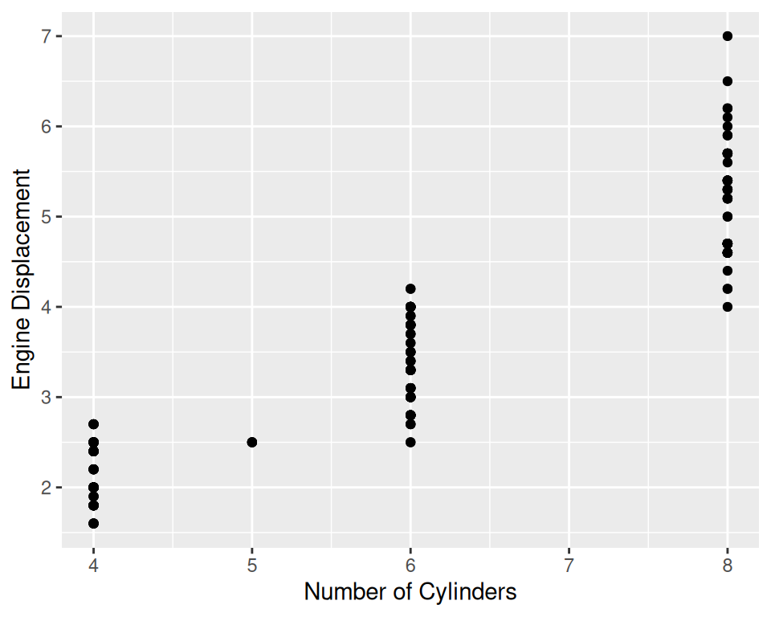

Figure 2: Engine displacement and numbers of cylinders for 38 popular car models from https://fueleconomy.gov. Engine displacement is given in litres.

Again, we reiterate that you should *not* use `ggtitle()` or `labs(title = ...)` to write your captions (or titles) in this course.

### 1.4.2 LibreOffice Writer

Please see [this guide](https://help.libreoffice.org/latest/lo/text/swriter/guide/captions.html).

### 1.4.3 OpenOffice Writer

Please see [this guide](https://wiki.openoffice.org/wiki/Documentation/OOoAuthors_User_Manual/Writer_Guide/Adding_captions_to_graphics).

### 1.4.4 Microsoft Word

Please see [this guide](https://support.microsoft.com/en-us/office/insert-a-caption-for-a-picture-bb74994c-7f8b-457c-be85-92233177a356).

# 2 Guide Titles

The guides (axes and legends) should almost always have titles. Titles should be informative and if it is not otherwise clear from the caption and they should also indicate the unit of measurement if it is not obvious from context. In Figure 1, for instance, the unit for fuel consumption is given in parentheses. In Figure 2, the unit of measurement is instead stated in the caption—which of the alternatives you choose is a matter of taste.

Sometimes it is obvious what the variable is and you may omit the guide title completely. Consider for instance a legend with color markers for “men”, “women”, and “other”. Here you may omit “gender” as title.

How to format the titles varies depending on the publication. Title or sentence case are the two most common choices, but lower case is typically okay too.

**title case**

A Nice Title of Something Important

**sentence case**

A nice title of something important

**lower case**

a nice title of something important

A title should not end with a period unless it is a full sentence (which you should typically avoid)

# 3 Figure Sizing

It is vital to size your figures appropriately. In this course we have seen many examples of otherwise excellent visualizations that have been garbled by incorrect sizing. This is always a shame to see since the time it takes to size your figures is a small fraction of the overall time it takes to construct a visualization.

There is no *one size fits all* for figures. Some figures need to be large, maybe even covering half or all of a page, while some figures can be kept much smaller. It usually depends on the complexity of the figures and the amount of ink you need to put on your canvas to visualize your data effectively.

## 3.1 Too Small

Making figures too small is the most common problem. If you have a lot of information, for instance a lot of observations to show or a multi-facet figure, then the more space you give your figure, the easier it will be to read it. You will even, to some extent, avoid overlapping between points that are near (but not on top of) each other. Many times you’ll benefit for allowing your figures to be as wide as the width of the text. (The only reason not to do so is really an aesthetic one, which, however, doesn’t make it invalid.)

## 3.2 Too Large

Making visualizations too large is possibly as common as making them too small and also has detrimental consequences—albeit for a different reason. The problem is usually that figures are made wider than the text width and to fit they (along with all text and markers) are shrunk to fit. The consequence of this is that the text can become illegible, which may in the worst case make the visualization altogether useless.

To combat this, always start with a figure width that is narrower than the text width. Then if you need you can increase the width incrementally until you reach the text width. If you use the R Markdown template we provide for the course, then you should never make your figures wider than 5.1 (inches). If you use one of the Office packages, then you can often right-click on the figure and check if the figure has been downsized, in which case you need to re-export with different settings.

## 3.3 How to Size your Figures

### 3.3.1 R Markdown

The size of figures can be controlled using the `fig.width` and `fig.height` options in the code chunk header. Below we show how to use these options in a R Markdown code chunk.

````
```{r, fig.cap = "A nice caption", fig.width = 4, fig.height = 3}
ggplot(...)
```
````

### 3.3.2 Office Packages (WYSIWYG Editors)

It may be tempting to use the built-in plot save function in R Studio, but we recommend against this because then you have to resize your figures manually each time you want to save the plot.